# Setup and use onlineforecast models

Peder Bacher

2020-09-07

## Intro

This vignette explains how to setup and use an onlineforecast model. This takes offset in the example of [building heat load forecasting](https://onlineforecasting.org/examples/building-heat-load-forecasting.html) and assumes that the data is setup correctly, as explained in setup-data vignette. The R code is available here. More information on onlineforecasting.org.

Start by loading the package:

```r
# Load the package
library(onlineforecast)
# Set the data in D to simplify notation
D <- Dbuilding
```

## Score period

Set the `scoreperiod` as a logical vector with same length as `t`. It controls which points are included in score calculations in functions for optimization etc. It must be set.

Use it to exclude a burn-in period of one week:

```r
# Print the first time point
D$t[1]
```

```
##     [1] "2010-12-15 01:00:00 GMT"
```

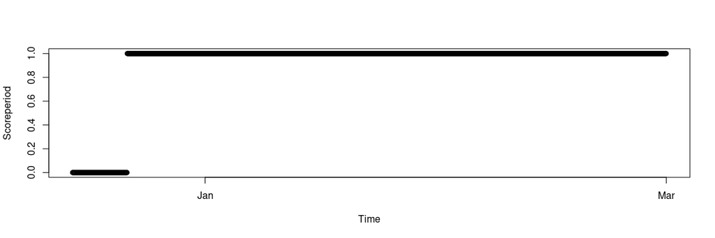

```r
# Set the score period
D$scoreperiod <- in_range("2010-12-22", D$t)
# Plot to see it
plot(D$t, D$scoreperiod, xlab="Time", ylab="Scoreperiod")
```

Other periods, which should be excluded from score calculations, can simply also be set to `FALSE`. E.g.:

```r
# Exclude other points example
scoreperiod2 <- D$scoreperiod
scoreperiod2[in_range("2010-12-30",D$t,"2011-01-02")] <- FALSE
```

would exclude the days around new year (must of course be set in `D$scoreperiod`, not in `scoreperiod2` to have an effect).

## Setting up a model

A simple onlineforecast model can be setup by:

```r
# Generate new object (R6 class)
model <- forecastmodel$new()
# Set the model output
model$output = "heatload"
# Inputs (transformation step)
model$add_inputs(Ta = "Ta",
                 mu = "one()")
# Regression step parameters
model$add_regprm("rls_prm(lambda=0.9)")
# Optimization bounds for parameters
model$add_prmbounds(lambda = c(0.9, 0.99, 0.9999))
# Set the horizons for which the model will be fitted
model$kseq <- c(3,18)
```

### Steps in setting up a model

Let’s go through the steps of setting up the model.

First a new forecastmodel object is generated and the model output is set (per default it is `"y"`):

```r
# Generate new object
model <- forecastmodel$new()
# Set the model output
model$output = "heatload"
```

The output is simply the variable name from `D` we want to forecast.

The model inputs are defined by:

```r
# Inputs (transformation step)
model$add_inputs(Ta = "Ta",
                 mu = "one()")
```

So this is really where the structure of the model is specified. The inputs are given a name (`Ta` and `mu`), which each are set as an R expression (given as a string). The expressions defines the **transformation step**: they will each be evaluated in an environment with a given `data.list`. This means that the variables from the data can be used in the expressions (e.g. `Ta` is in `D`) - below in Input transformations we will detail this evaluation.

Next step for setting up the model is to set the parameters for the **regression step** by providing an expression, which returns the regression parameter values. In the present case we will use the Recursive Least Squares (RLS) when regressing, and we need to set the forgetting factor `lambda` by:

```r
# Regression step parameters
model$add_regprm("rls_prm(lambda=0.9)")
```

The expression is just of a function, which returns a list - in this case with the value of `lambda` (see [onlineforecasting](https://onlineforecasting.org/articles/onlineforecasting.pdf)). The result of it begin evaluated is kept in:

```r
# The evaluation happens with
eval(parse(text="rls_prm(lambda=0.9)"))
```

```
##     $lambda
##     [1] 0.9
```

```r
# and the result is stored in
model$regprm
```

```
##     $lambda
##     [1] 0.9
```

We will tune the parameters, for this model it’s only the forgetting factor, so we set the parameter bounds (lower, init, upper) for it by:

```r
# Optimization bounds for parameters
model$add_prmbounds(lambda = c(0.9, 0.99, 0.9999))
```

Finally, we set the horizons for which to fit:

```r
# Set the horizons for which the model will be fitted
model$kseq <- c(3,18)
```

The horizons to fit for is actually not directly related to the model, but rather the fitting of the model. In principle, it would be more “clean” if the model, data and fit was kept separate, however for recursive fitting this becomes un-feasible.

### Tune the parameters

We have set up the model and can now tune the `lambda` with the `rls_optim()`, which is a wrapper for the `optim()` function:

```r
# Call the optim() wrapper
model$prm <- rls_optim(model, D)$par
```

```
##     ----------------
##     lambda
##       0.99
##        k3   k18   sum
##     0.831 0.826 1.657
##     ----------------
##     lambda
##      0.991
##        k3   k18   sum
##     0.831 0.827 1.658
##     ----------------
##     lambda
##      0.989
##        k3   k18   sum
##     0.831 0.826 1.657
##     ----------------
##     lambda
##        0.9
##        k3   k18   sum
##     0.885 0.904 1.789
##     ----------------
##     lambda
##      0.901
##        k3   k18   sum
##     0.884 0.903 1.787
##     ----------------
##     lambda
##        0.9
##        k3   k18   sum
##     0.885 0.904 1.789
##     ----------------
##     lambda
##      0.981
##        k3   k18   sum
##     0.832 0.825 1.657
##     ----------------
##     lambda
##      0.982
##        k3   k18   sum
##     0.831 0.825 1.657
```

[output cut: 290 more lines]

```
##     ----------------
##     lambda
##      0.985
##        k3   k18   sum
##     0.831 0.825 1.656
##     ----------------
##     lambda
##      0.986
##        k3   k18   sum
##     0.831 0.825 1.656
##     ----------------
##     lambda
##      0.984
##        k3   k18   sum
##     0.831 0.825 1.656
```

Note, how it only calculated a score for the 3 and 18 steps horizons - as we specified with `model$kseq` above. The parameters could be optimized separately for each horizon, for example it is often such that for the first horizons a very low forgetting factor is optimal (e.g. 0.9). Currently, however, the parameters can only be optimized together. By optimizing for a short (3 steps) and a long horizon (18 steps), we obtain a balance - using less computations compared to optimizing on all horizons.

The optimization converge and the tuned parameter becomes:

```r
# Optimized lambda
model$prm
```

```
##     lambda
##      0.985
```

Now we can fit with the optimized `lambda` on all horizons over the entire period:

```r
# Set to fit for all horizons
model$kseq <- 1:36
# Fit for all on entire period in D
fit1 <- rls_fit(model$prm, model, D)
```

```
##     ----------------
##     lambda
##      0.985
```

See the summary of the fit:

```r
# See the summary of the fit
summary(fit1)
```

```
##
##     Output: heatloadInputs: Ta = Ta
##             mu = one()
##
##     Regression parameters:
##          lambda = 0.985
##
##     Scoreperiod: 1656 observations are included.
##
##     RLS coeffients summary stats (cannot be used for significance tests):
##         mean    sd   min  max
##     Ta -0.14 0.044 -0.26 0.19
##     mu  5.20 0.280  4.50 6.80
##
##     RMSE:
##       k1   k2   k3   k4   k5   k6   k7   k8   k9  k10  k11  k12  k13  k14  k15  k16
##     0.82 0.83 0.83 0.83 0.83 0.84 0.84 0.84 0.84 0.84 0.83 0.83 0.83 0.83 0.83 0.83
##      k17  k18  k19  k20  k21  k22  k23  k24  k25  k26  k27  k28  k29  k30  k31  k32
##     0.83 0.83 0.83 0.82 0.83 0.83 0.83 0.84 0.85 0.86 0.86 0.86 0.86 0.86 0.86 0.86
##      k33  k34  k35  k36
##     0.86 0.86 0.86 0.86
```

See `?summary.rls_fit` for details.

Plot the forecasts (`Yhat` adheres to the forecast matrix format and in `plot_ts()` the forecasts are lagged `k` steps to be aligned with the observations):

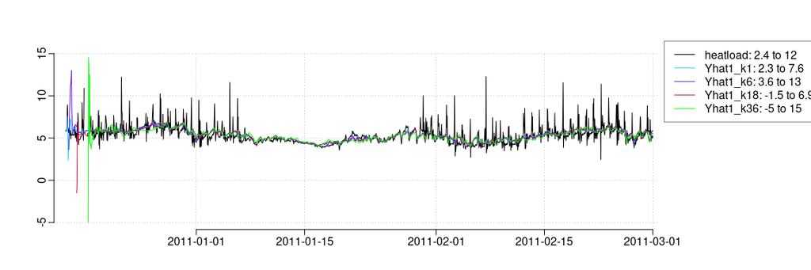

```r
# Put the forecasts in D
D$Yhat1 <- fit1$Yhat
# Plot them for selected horizons
plot_ts(D, c("^heatload$|^Y"), kseq = c(1,6,18,36))
```

We clearly see the burn-in period, where the forecasts vary a lot,

Plot a forecast for a particular time point and forward in time:

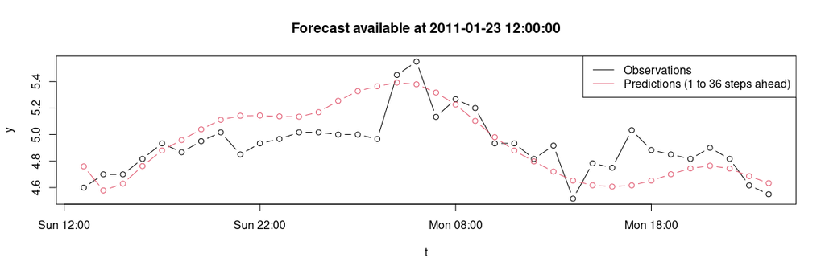

```r
# Select a point
i <- 996-48
# and kseq steps ahead
iseq <- i+model$kseq
# The observations ahead in time
plot(D$t[iseq], D$heatload[iseq], type = "b", xlab = "t", ylab = "y")
title(main=pst("Forecast available at ",D$t[i]))
# The forecasts
lines(D$t[iseq], D$Yhat1[i, ], type = "b", col = 2)
legend("topright", c("Observations",pst("Predictions (",min(model$kseq)," to ",max(model$kseq)," steps ahead)")), lty = 1, col = 1:2)
```

## Input transformations

The inputs can be transformations of the variables in the data, i.e. `D` in this example. The function `one()` generate a forecast matrix of 1 for the needed horizons. It cannot be called directly:

```r
# This will give error
one()
```

(the code above was not executed)

however we can see the result of the evaluation by:

```r
# Evaluate input expressions
datatr <- model$transform_data(D)
# See what came out
summary(datatr)
```

```
##        Length Class      Mode
##     Ta 36     data.frame list
##     mu 36     data.frame list
```

```r
# In particular for the mu = "one()"
head(datatr$mu)
```

```
##       k1 k2 k3 k4 k5 k6 k7 k8 k9 k10 k11 k12 k13 k14 k15 k16 k17 k18 k19 k20 k21
##     1  1  1  1  1  1  1  1  1  1   1   1   1   1   1   1   1   1   1   1   1   1
##     2  1  1  1  1  1  1  1  1  1   1   1   1   1   1   1   1   1   1   1   1   1
##     3  1  1  1  1  1  1  1  1  1   1   1   1   1   1   1   1   1   1   1   1   1
##     4  1  1  1  1  1  1  1  1  1   1   1   1   1   1   1   1   1   1   1   1   1
##     5  1  1  1  1  1  1  1  1  1   1   1   1   1   1   1   1   1   1   1   1   1
##     6  1  1  1  1  1  1  1  1  1   1   1   1   1   1   1   1   1   1   1   1   1
##       k22 k23 k24 k25 k26 k27 k28 k29 k30 k31 k32 k33 k34 k35 k36
##     1   1   1   1   1   1   1   1   1   1   1   1   1   1   1   1
##     2   1   1   1   1   1   1   1   1   1   1   1   1   1   1   1
##     3   1   1   1   1   1   1   1   1   1   1   1   1   1   1   1
##     4   1   1   1   1   1   1   1   1   1   1   1   1   1   1   1
##     5   1   1   1   1   1   1   1   1   1   1   1   1   1   1   1
##     6   1   1   1   1   1   1   1   1   1   1   1   1   1   1   1
```

If we wanted to debug we could:

```r
# Set to debug
#debug(one)
# Run the input transformation now and it will stop in one()
datatr <- model$transform_data(D)
# Set to undebug
#undebug(one)
```

(the code above was not executed).

Let’s extend the model by adding a low-pass filter transformation of the ambient temperature forecasts. We could just update the input by:

```r
# Just update the Ta input by
model$add_inputs(Ta = "lp(Ta, a1=0.9)")
```

but let’s just repeat the whole model definition for clarification - including the new transformation:

```r
# Define a new model with low-pass filtering of the Ta input
model <- forecastmodel$new()
model$output = "heatload"
model$add_inputs(Ta = "lp(Ta, a1=0.9)",
                 mu = "one()")
model$add_regprm("rls_prm(lambda=0.9)")
model$add_prmbounds(Ta__a1 = c(0.5, 0.9, 0.9999),
                    lambda = c(0.9, 0.99, 0.9999))
model$kseq <- c(3,18)
```

Note how also a new set of parameter bounds were added in `add_prmbounds()` following a neat little syntax: `Ta__a1` indicates that the first appearance of `a1` in the `Ta` input expression, will be changed in the optimization.

We can see the parameter bounds with:

```r
model$prmbounds
```

```
##            lower init upper
##     Ta__a1   0.5 0.90     1
##     lambda   0.9 0.99     1
```

To inspect the result of low-pass filtering:

```r
# Low-pass filter Ta (with a1=0.9 as defined above)
datatr <- model$transform_data(D)
# Actually, lp() can be called directly (although two warnings are thrown)
Talp <- lp(D$Ta, a1=0.99)
```

```
##     Warning in state_getval(initval = yInit): In state_getval() the object of class
##     input was not found in the parent environments. The initval was returned.
##     Warning in state_setval(val[nrow(X), ]): In state_setval() the object of class
##     input was not found in the parent environments, so the state value could not be
##     updated.
```

and to see the result we could:

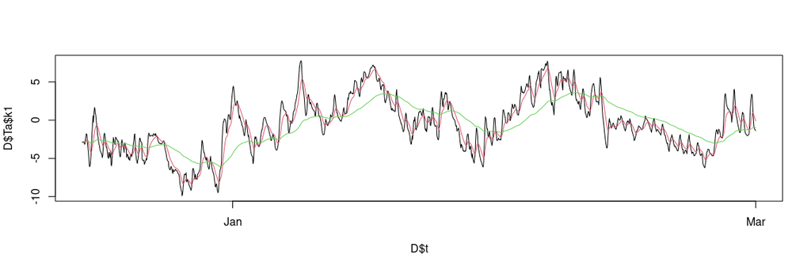

```r
# Plot the Ta$k1 forecasts
plot(D$t, D$Ta$k1, type="l")
# Add the filtered with a1=0.9
lines(D$t, datatr$Ta[ ,"k1"], col=2)
# Add the filtered with a1=0.99
lines(D$t, Talp[ ,"k1"], col=3)
```

hence with a low-pass coefficient `a1=0.99`, which is very high (max is 1), the Ta forecast is really smoothed, which models a system with a time constant (i.e. slow dynamics, e.g. well insulated and building with lots of concrete).

There are quite a few functions available for input transformations:

- `one()` generates an matrix of ones (for including an intercept).
- `fs()` generate Fourier series for modelling harmonic functions.
- `bspline()` wraps the `bs()` function for generating base splines.
- `AR()` generates auto-regressive model inputs.

and they can even be combined, see more details in [onlineforecasting](https://onlineforecasting.org/articles/onlineforecasting.pdf) and in their help description, e.g. `?fs`.

Tuning the two parameters: the low-pass filter coefficient `a1` and the forgetting factor `lambda`, can now be done:

```r
# Optimize the parameters
model$prm <- rls_optim(model, D)$par
```

```
##     ----------------
##     Ta__a1 lambda
##       0.90   0.99
##        k3   k18   sum
##     0.823 0.817 1.640
##     ----------------
##     Ta__a1 lambda
##      0.901  0.990
##        k3   k18   sum
##     0.823 0.817 1.640
##     ----------------
##     Ta__a1 lambda
##      0.899  0.990
##        k3   k18   sum
##     0.823 0.817 1.639
##     ----------------
##     Ta__a1 lambda
##      0.900  0.991
##        k3   k18   sum
##     0.822 0.817 1.639
##     ----------------
##     Ta__a1 lambda
##      0.900  0.989
##        k3   k18   sum
##     0.824 0.816 1.640
##     ----------------
##     Ta__a1 lambda
##      0.822  1.000
##        k3   k18   sum
##     0.832 0.832 1.664
##     ----------------
##     Ta__a1 lambda
##      0.823  1.000
##        k3   k18   sum
##     0.832 0.832 1.663
##     ----------------
##     Ta__a1 lambda
##      0.821  1.000
##        k3   k18   sum
##     0.832 0.832 1.664
```

[output cut: 195 more lines]

```
##     ----------------
##     Ta__a1 lambda
##      0.849  0.991
##        k3   k18   sum
##     0.822 0.816 1.638
##     ----------------
##     Ta__a1 lambda
##      0.850  0.992
##        k3   k18   sum
##     0.822 0.816 1.638
##     ----------------
##     Ta__a1 lambda
##       0.85   0.99
##        k3   k18   sum
##     0.822 0.816 1.638
```

Plot the forecasts (Yhat adheres to the forecast matrix format and in `plot_ts` the forecasts are lagged `k` steps to sync with the observations)

```r
# Fit for all horizons
model$kseq <- 1:36
# Fit with RLS
fit2 <- rls_fit(model$prm, model, D)
```

```
##     ----------------
##     Ta__a1 lambda
##      0.850  0.991
```

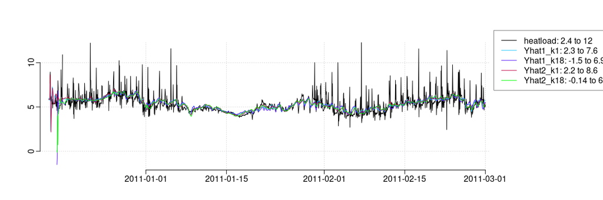

```r
# Take the forecasts
D$Yhat2 <- fit2$Yhat
# Plot all
plot_ts(D, c("^heatload$|^Y"), kseq = c(1,18))
```

We can see the summary:

```r
summary(fit2)
```

```
##
##     Output: heatloadInputs: Ta = lp(Ta, a1=0.85)
##             mu = one()
##
##     Regression parameters:
##          lambda = 0.991
##
##     Scoreperiod: 1656 observations are included.
##
##     RLS coeffients summary stats (cannot be used for significance tests):
##         mean    sd   min   max
##     Ta -0.17 0.036 -0.29 0.016
##     mu  5.20 0.180  4.80 6.000
##
##     RMSE:
##       k1   k2   k3   k4   k5   k6   k7   k8   k9  k10  k11  k12  k13  k14  k15  k16
##     0.81 0.82 0.82 0.82 0.82 0.82 0.82 0.82 0.82 0.82 0.82 0.82 0.82 0.82 0.82 0.82
##      k17  k18  k19  k20  k21  k22  k23  k24  k25  k26  k27  k28  k29  k30  k31  k32
##     0.82 0.82 0.82 0.82 0.82 0.82 0.82 0.82 0.83 0.83 0.83 0.83 0.83 0.83 0.83 0.83
##      k33  k34  k35  k36
##     0.83 0.83 0.83 0.83
```

but more interesting is it to see if an improvement was achieved with the low-pass filtering, so calculate the RMSE for both models:

```r
# Calculate the score
RMSE1 <- summary(fit1, printit=FALSE)$scoreval
RMSE2 <- summary(fit2, printit=FALSE)$scoreval
```

Now, this is calculated for the points included in the `scoreperiod`, so it’s important to make sure that exactly the same values are forecasted. A check can be done by:

```r
# Check that all NAs in the scoreperiod are at the same positions
all(is.na(fit1$Yhat[fit1$data$scoreperiod, ]) == is.na(fit2$Yhat[fit2$data$scoreperiod, ]))
```

```
##     [1] TRUE
```

Finally, plot the RMSE for the two models:

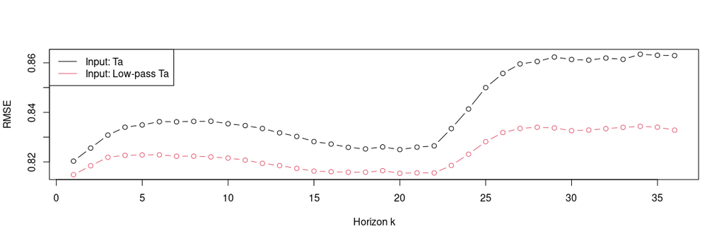

```r
# Plot the score for the two models
plot(RMSE1, xlab="Horizon k", ylab="RMSE", type="b", ylim=range(RMSE1,RMSE2))
lines(RMSE2, type="b", col=2)
legend("topleft", c("Input: Ta","Input: Low-pass Ta"), lty=1, col=1:2)
```

We can see, that we obtained improvements. Around 3-4% for the longer horizons.

For more on evaluation, see the vignette forecast-evaluation.

See more on how to extend this model even further in [building heat load forecasting](https://onlineforecasting.org/examples/building-heat-load-forecasting.html).

## Time of day and using observations as input

### Time of day as input

Often we need to have the time of day as an input to a forecastmodel:

```r
make_tday(D$t, kseq=1:3)
```

```
##          k1 k2 k3
##     1     2  3  4
##     2     3  4  5
##     3     4  5  6
##     4     5  6  7
##     5     6  7  8
##     6     7  8  9
##     7     8  9 10
##     8     9 10 11
##     9    10 11 12
##     10   11 12 13
##     11   12 13 14
##     12   13 14 15
##     13   14 15 16
##     14   15 16 17
##     15   16 17 18
##     16   17 18 19
##     17   18 19 20
##     18   19 20 21
##     19   20 21 22
##     20   21 22 23
##     21   22 23  0
##     22   23  0  1
##     23    0  1  2
##     24    1  2  3
##     25    2  3  4
##     26    3  4  5
##     27    4  5  6
## ...output cropped
```

So we can use it like this:

```r
D$tday <- make_tday(D$t, 1:36)
```

See the help `?make_tday` for more details.

### Using observations as input

If we want to use observations in inputs to a model, we can use e.g.:

```r
D$Tao <- make_input(D$Taobs, kseq=1:36)
model$add_inputs(Tao = "lp(Tao, a1=0.99)")
```

## Caching of optimized parameters

Working with time consuming calculations caching can be very valuable. The optimization results can be cached by providing a path to a directory, by setting the argument ‘cachedir’ to e.g. “cache”. See the vignette [nice-tricks](https://onlineforecasting.org/vignettes/nice-tricks.html) for an example with code.

## Deep clone model

Usually, an object of an R6 class can be copied (in memory) deeply with ‘$clone(deep=TRUE)’, however that will result in problems with the forecastmodels, therefore the deep clone must be done by:

```r
m1 <- model$clone_deep()
```

See `?R6` for details on R6 objects.